# Analyse des engagements

Elections municipales 2026

Published

April 14, 2026

## Introduction

En février 2026, l’AAF a appelé les candidat·es des élections municipales à prendre position en faveur des archives communales : [lien vers le communiqué de presse](https://www.archivistes.org/elections-2026-laaf-appelle-les-futur-es-maires-a-sengager-en-faveur-des-archives-communales/).

190 candidat·es ont répondu à cet appel.

En complément de la carte présentant la répartition géographique des personnes ayant répondu à l’appel, voici quelques éléments d’analyses.

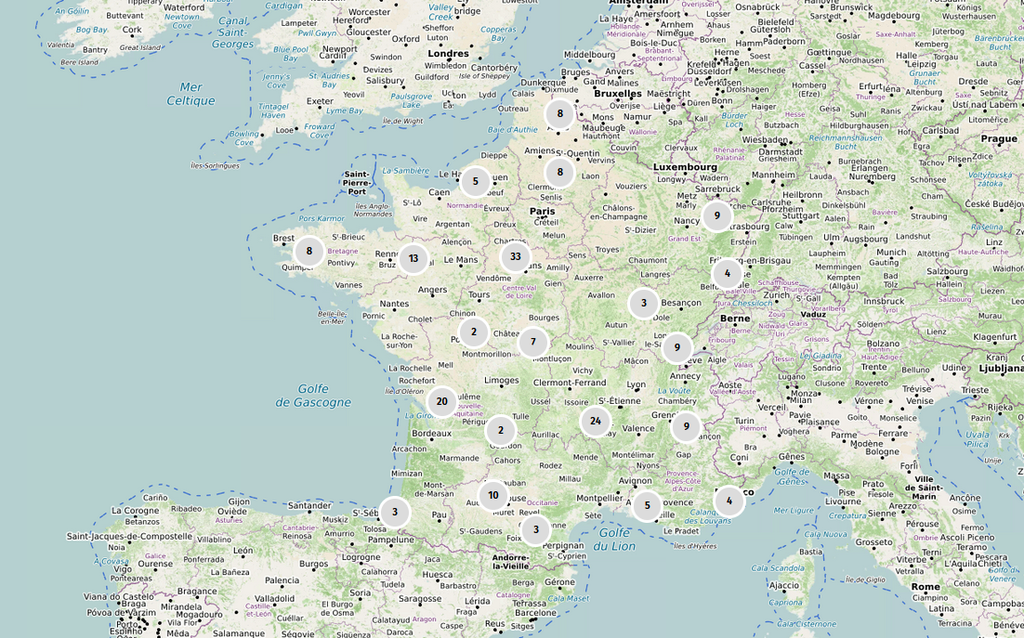

Voir en plein écran

## Dates d’engagement

L’appel a eu lieu entre le mois de février et mars 2026[^1].

<sup>1</sup> [Fichier consolidé des données utilisé](https://github.com/ALDonzel/AAF-municipales-2026/blob/main/engagement_final.csv).

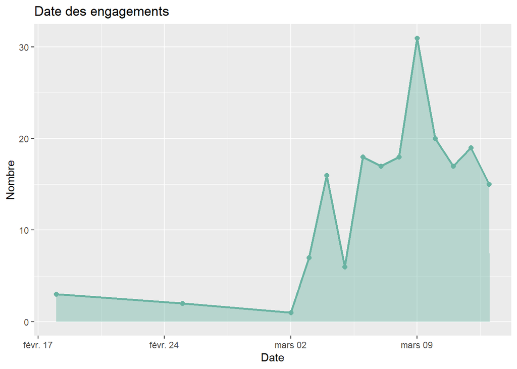

## Répartition genrées

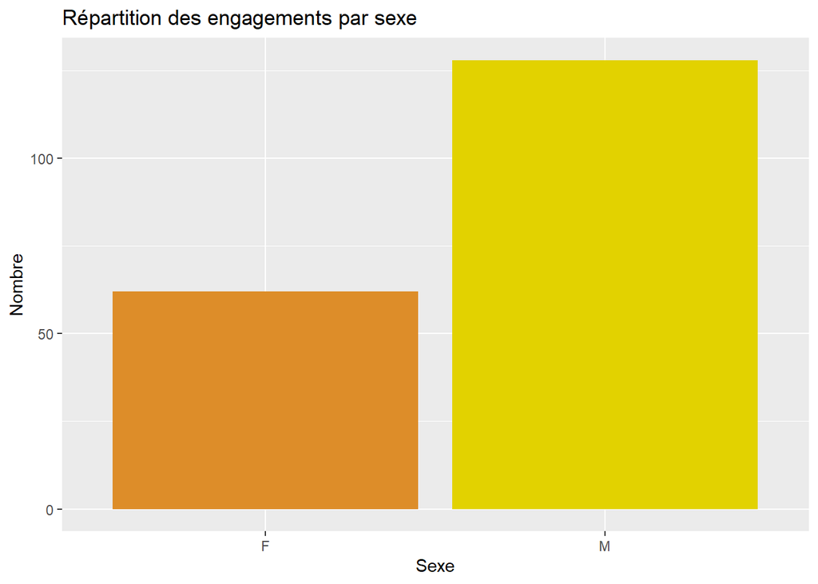

## Position sur la liste

Une très large partie des réponses proviennent de tête de liste.

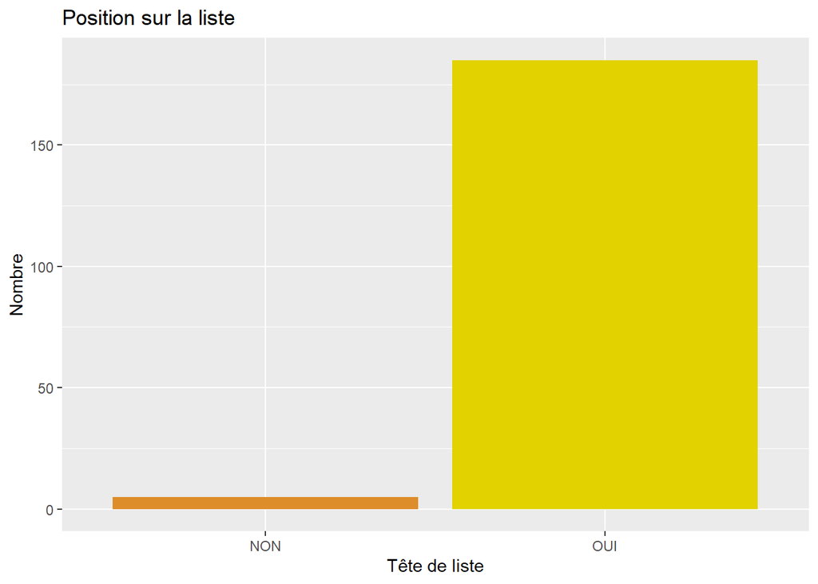

## Les nuances de liste

La liste des nuances est celle présente au sein des données du Ministère de l’Intérieur[^2].

<sup>2</sup> Jointure avec le jeu de données [Elections municipales 2026 - Listes candidates au premier tour](https://static.data.gouv.fr/resources/elections-municipales-2026-listes-candidates-au-premier-tour/20260313-152615/municipales-2026-candidatures-france-entiere-tour-1-2026-03-13.csv) du Ministère de l’Intérieur.

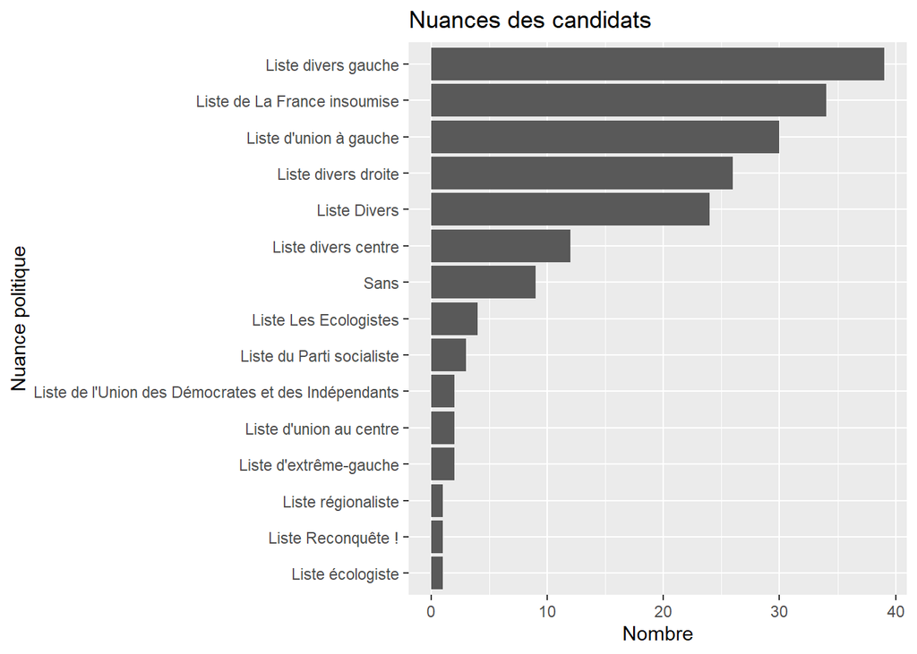

## Les personnes engagées ont-elles été élues ?

La liste des personnes élues est réalisée à partir des données des deux tours[^3]. Ici, la notion de “personnes élues” désigne toutes celles et ceux qui, à l’issu des deux tours, siègent au conseil municipal. Ces personnes peuvent donc être élues de la liste arrivée en tête ou des listes d’opposition.

<sup>3</sup> Jointure réalisée avec les données des résultats publiées par le Ministère de l’Intérieur du [premier](https://static.data.gouv.fr/resources/elections-municipales-2026-resultats-du-premier-tour/20260320-164100/municipales-2026-candidats-elus-france-entiere-tour-1-2026-03-20.csv) et du [second](https://static.data.gouv.fr/resources/elections-municipales-2026-resultats-du-scond-tour/20260323-180122/municipales-2026-candidats-elus-france-entiere-tour-2-2026-03-23.csv) tour.

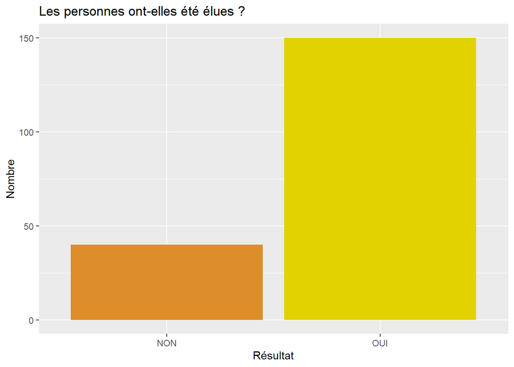